# La demografía del parentesco: una introducción práctica

### Ejercicio ‘a mano’

Replica los resultados anteriores utilizando la función `kin_multi_stage.R`. Esto se puede obtener de [aquí](https://github.com/alburezg/taller_parentesco_COLMEX_2023/tree/master/docs). Para los argumentos `U`, `f`, `H` y `D` de la función, usa los objetos que creaste anteriormente (esto funciona porque la función puede manejar listas como las que creamos):

```r
# entradas para la función kin_multi_stage
U <- list(U_0, U_1, U_2, U_3, U_4)
H <- list(H_low, H_high)
D <- list(D_low, D_high)
f <- F. <- lapply(1:ages, function(x){
  matrix(c(f_low[x],0,f_high[x],0),2, 2)
  })
```

Debes establecer `birth_female = 1` porque la fecundidad ya se refiere a las hijas. Dado que el análisis no es de distribución de paridad, establece `parity = FALSE`.

**Mostrar**

```r
source("kin_multi_stage.R")

# create lists
U <- list(U_0, U_1, U_2, U_3, U_4)
H <- list(H_low, H_high)
D <- list(D_low, D_high)
F. <- lapply(1:ages, function(x){
  matrix(c(f_low[x],0,f_high[x],0),2, 2)
  })

# run model
demokin_multistage <- kin_multi_stage(U, F., D, H, birth_female = 1, parity = FALSE, output_kin = c("m","d"))

# get summary
demokin_multistage_summary <- demokin_multistage %>%
  group_by(kin, age_focal, stage_kin) %>%
  summarise(living = sum(living, na.rm=T))
# compare
demokin_multistage_summary %>% filter(kin == "d") %>% arrange(stage_kin, age_focal) %>% pull(living) - c(A_stage[1,],A_stage[2,])
```

```
##  [1]  0.000000e+00  0.000000e+00  0.000000e+00  0.000000e+00 -1.110223e-16
##  [6]  0.000000e+00  0.000000e+00  0.000000e+00  0.000000e+00  0.000000e+00
```

```r
demokin_multistage_summary %>% filter(kin == "m") %>% arrange(stage_kin, age_focal) %>% pull(living) - c(D_stage[1,],D_stage[2,])
```

```
##  [1]  0.000000e+00  0.000000e+00  0.000000e+00  0.000000e+00  0.000000e+00
##  [6]  0.000000e+00 -1.387779e-17  0.000000e+00  0.000000e+00  0.000000e+00
```

## Soluciones

#### Lunes 24

**1.1**

**Mostrar**

```r
# Escribe tu código aquí
swe_surv_1910 <- DemoKin::swe_px[,"1910"]
swe_asfr_1910 <- DemoKin::swe_asfr[,"1910"]
swe_1910 <- kin(p = swe_surv_1910, f = swe_asfr_1910, time_invariant = TRUE)
swe_1910$kin_summary %>%
  summarise(count_living = round(sum(count_living),3), .by = c(kin, age_focal)) %>%
  filter(age_focal == 35, kin == "d")
```

```
## # A tibble: 1 × 3
##   kin   age_focal count_living
##   <chr>     <int>        <dbl>
## 1 d            35         1.08
```

**1.2**

**Mostrar**

```r
# Escribe tu código aquí
swe_1910$kin_summary %>%
  summarise(count_living = round(sum(count_living),3), .by = c(kin, age_focal)) %>%
  filter(age_focal == 35, kin == "m")
```

```
## # A tibble: 1 × 3
##   kin   age_focal count_living
##   <chr>     <int>        <dbl>
## 1 m            35        0.679
```

**1.3**

**Mostrar**

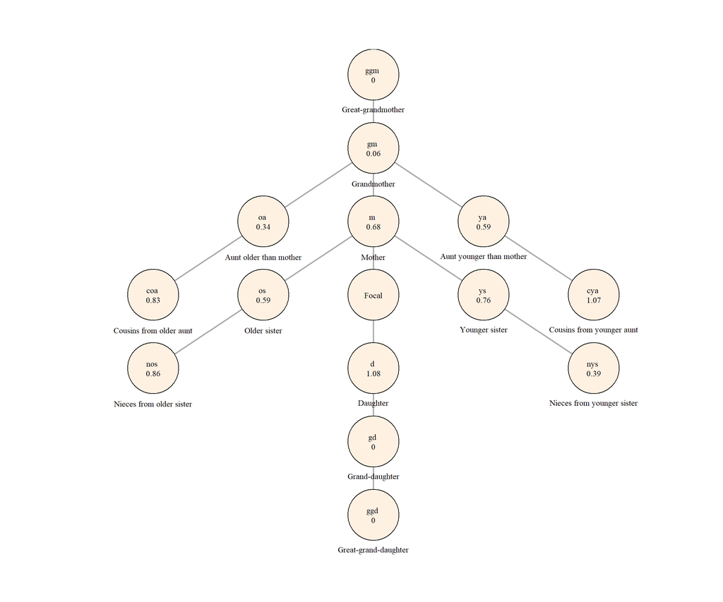

```r
# Escribe tu código aquí
swe_1910$kin_summary %>%
  filter(age_focal == 35) %>%
  select(kin, count = count_living) %>%
  plot_diagram(rounding = 2)
```

**1.4**

**Mostrar**

```r
swe_1910$kin_summary %>%
  filter(age_focal == 65, kin == "d") %>%
  select(age_focal, loss_1910 = count_cum_dead) %>%
  inner_join(
    swe_2015$kin_summary %>%
      filter(age_focal == 65, kin == "d") %>%
      select(age_focal, loss_2015 = count_cum_dead))
```

```
## # A tibble: 1 × 3
##   age_focal loss_1910 loss_2015
##       <int>     <dbl>     <dbl>
## 1        65     0.368   0.00784
```

**2.1**

**Mostrar**

```r
mean_ages_2015 <- swe_2015$kin_full %>%
  filter(age_focal == 35) %>%
  summarise(mean_age = sum(age_kin*living)/sum(living),
            .by = c(kin))
mean_ages_2015
```

```
## # A tibble: 14 × 2
##    kin   mean_age
##    <chr>    <dbl>
##  1 d        5.52
##  2 gd       0.417
##  3 ggd    NaN
##  4 m       65.4
##  5 gm      88.6
##  6 ggm     96.9
##  7 os      40.2
##  8 ys      28.5
##  9 nos      9.72
## 10 nys      3.80
## 11 oa      70.0
## 12 ya      58.9
## 13 coa     39.2
## 14 cya     27.6
```

**2.2**

**Mostrar**

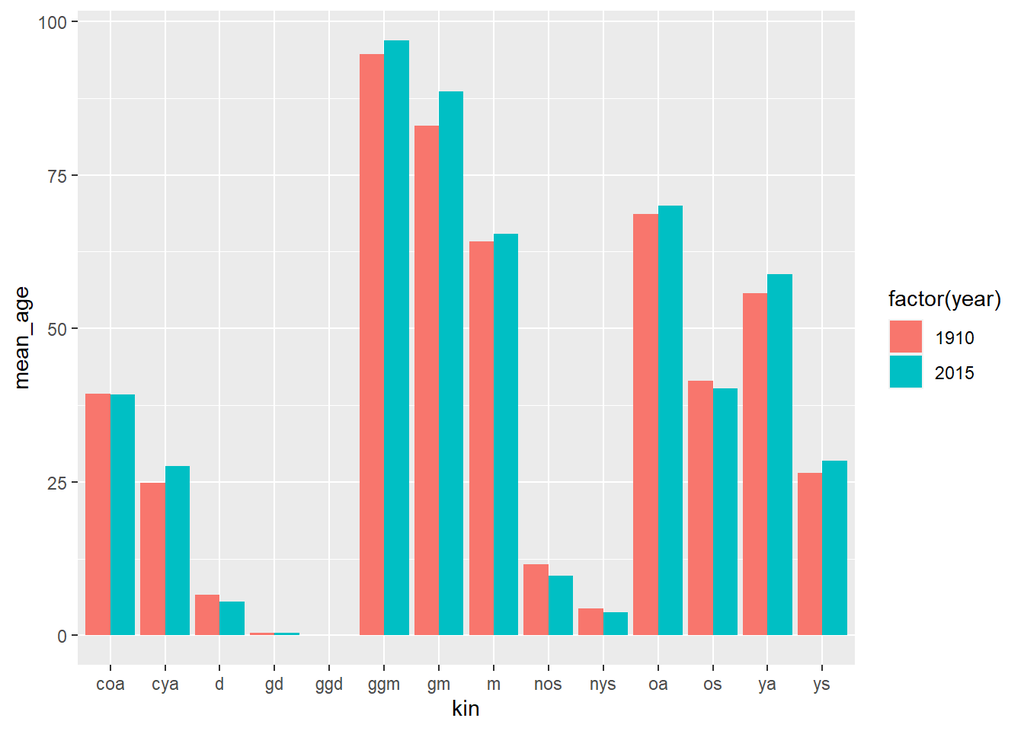

```r
mean_ages_1910 <- swe_1910$kin_full %>%
  filter(age_focal == 35) %>%
  summarise(mean_age = sum(age_kin*living)/sum(living),
            .by = c(kin))
# one posible plot
mean_ages_1910 %>%
  mutate(year = 1910) %>%
  bind_rows(
    mean_ages_2015 %>% mutate(year = 2015)) %>%
  ggplot() +
  geom_bar(aes(kin, mean_age, fill=factor(year)),
           stat = "identity", position = "dodge")
```

**2.3**

**Mostrar**

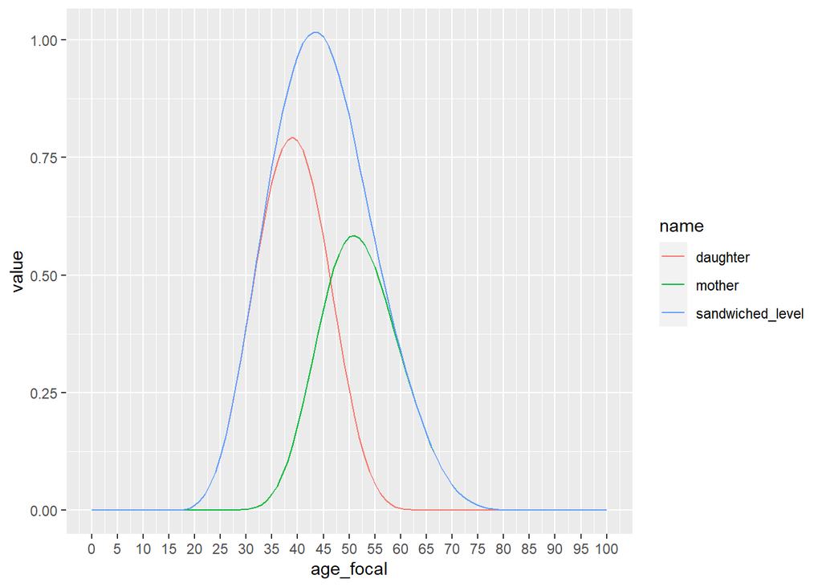

```r
swe_2015$kin_full %>%
  group_by(age_focal) %>%
  summarise(daughter = sum(living[kin=='d' & age_kin<=15]),
            mother = sum(living[kin=='m' & age_kin>=75]),
            sandwiched_level = daughter + mother) %>%
  pivot_longer(cols = daughter:sandwiched_level) %>%
  ggplot()+
  geom_line(aes(age_focal, value, col=name))+
  scale_x_continuous(labels = seq(0,100,5), breaks = seq(0,100,5))
```

**3.1**

**Mostrar**

```r
age <- 0:4
p <- c(.9, .7, .4, .1, 0)
f <- c(0, .5, .5, .3, 0)
by_hand_example <- kin(p, f, birth_female = 1)
# some checks
by_hand_example$kin_summary %>% filter(kin == "gm") %>% pull(count_living) - g
```

```
##              [,1] [,2] [,3] [,4] [,5]
## [1,] 5.551115e-17    0    0    0    0
```

```r
by_hand_example$kin_summary %>% filter(kin == "m") %>% pull(count_living) - d
```

```
##      [,1] [,2] [,3] [,4] [,5]
## [1,]    0    0    0    0    0
```

```r
by_hand_example$kin_summary %>% filter(kin == "d") %>% pull(count_living) - a
```

```
##      [,1] [,2] [,3] [,4] [,5]
## [1,]    0    0    0    0    0
```

```r
# grandmothers
by_hand_example$kin_summary %>% filter(kin == "gm") %>% pull(count_living)
```

```
## [1] 0.333379039 0.087814545 0.007430031 0.000000000 0.000000000
```